# Modelling with SARIMA: example 2

Maria Eduarda Silva

LMU, July 1 2022

# Modelling Total Private Residential Construction Spending

## Introduction

Build a model for the monthly Total Private Residential Construction Spending data following the Box-Jenkins methodology. The data set is available in The Federal Bank of St Louis.

```r
library(astsa)
library(xts)
library(zoo)
library(forecast)
library(Quandl)
Quandl.api_key("XzdSwkDsE98Mxj3ixQzG")
# Total Private Residential Construction Spending : FRED/PRRESCON
```

## Data

Data for this model are imported from Quandl website (FRED/PRRESCON).

```r
prc <- Quandl("FRED/PRRESCON", type = "zoo")
y=prc
str(y)
```

```
## 'zooreg' series from Jan 1993 to Dec 2021
##   Data: num [1:348] 13430 12141 14007 15762 17390 ...
##   Index:  'yearmon' num [1:348] Jan 1993 Feb 1993 Mar 1993 Apr 1993 ...
##   Frequency: 12
```

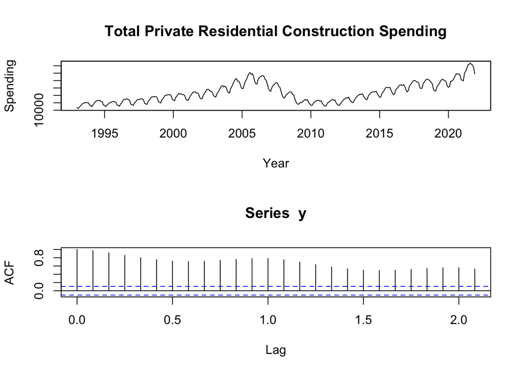

```r
par(mfrow = c(2, 1))
plot(y, xlab="Year", ylab="Spending", main="Total Private Residential Construction Spending")
acf(y)
```

This time series shows the seasonality and trend so we need to consider a seasonal AR or MA component as well as a regular AR or MA component. The variability seems to change somewhat over time so I will consider also the logged data. First choose train set and test set.

```r
yall<-window(y, end=2016+11/12)
fstM <- 1993+0/12
lstM <- 2013+11/12
y1 <- window(yall, end=lstM)
y2 <- window(yall, start=lstM+1/12)
```

Now consider the training set and its log.

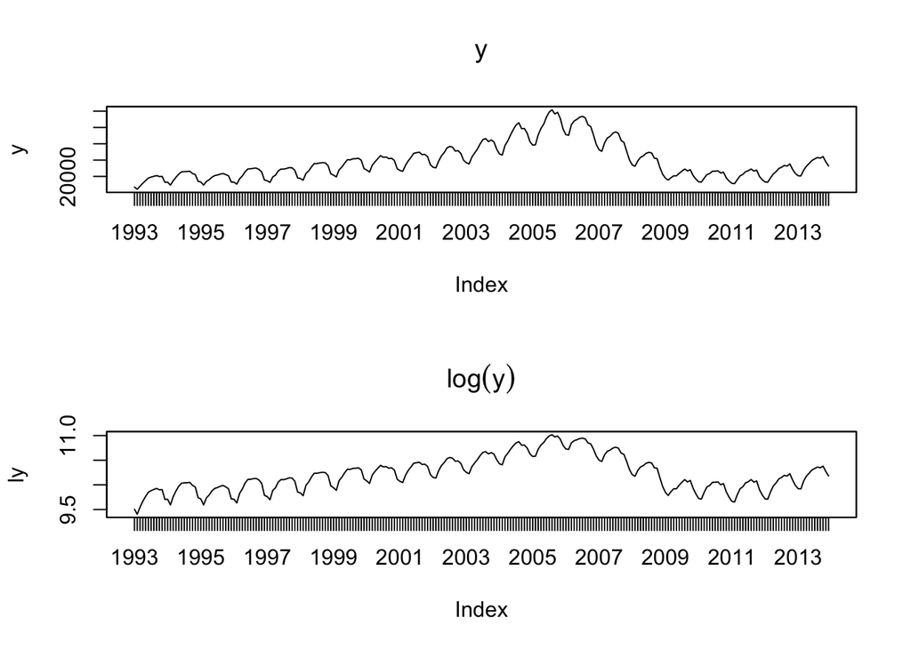

```r
y<- y1
ly <- log(y)

# Original and transformed data
par(mfrow = c(2, 1))
plot(y, main = expression(y))
plot(ly, main = expression(log(y)))
```

The logged data looks more stable. From now we study logged data. To find out the best SARIMA$(p,d,q)\times (P,D,Q)_{12}$ we study the acf and pacf of the differenced data with $d=1,$ $D=1,$ $d=1 $ and $D=1$. Plot the data and its acf and pacf.

```r
dly1 <- diff(ly)
dly12 <- diff(ly,12)
dly12_1 <- diff(diff(ly),12)
```

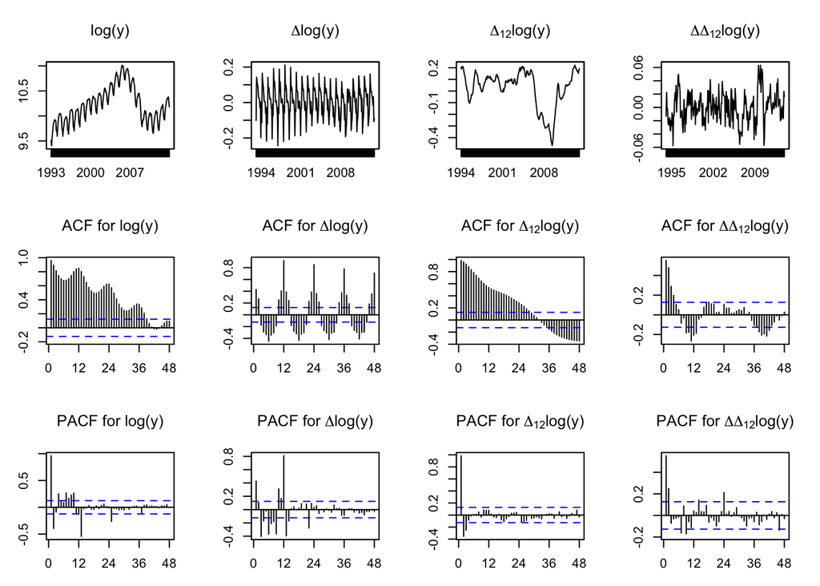

```r
maxlag <- 48
par(mfrow=c(3,4), mar=c(3,3,4,2))

plot(ly, main = expression("log(y)"))
plot(dly1, main = expression(paste(Delta, "log(y)")))
plot(dly12, main = expression(paste(Delta[12], "log(y)")))
plot(dly12_1, main = expression(paste(Delta, Delta[12], "log(y)")))

Acf(ly, type='correlation', lag=maxlag, ylab="", main=expression(paste("ACF for log(y)")))
Acf(dly1, type='correlation', lag=maxlag, na.action=na.omit, ylab="", main=expression(paste("ACF for ", Delta,"log(y)")))
Acf(dly12, type='correlation', lag=maxlag, na.action=na.omit, ylab="", main=expression(paste("ACF for ", Delta[12], "log(y)")))
Acf(dly12_1, type='correlation', lag=maxlag, na.action=na.omit, ylab="", main=expression(paste("ACF for ", Delta, Delta[12], "log(y)")))

Acf(ly, type='partial', lag=maxlag, na.action=na.omit, ylab="", main=expression(paste("PACF for log(y)")))
Acf(dly1, type='partial', lag=maxlag, na.action=na.omit, ylab="", main=expression(paste("PACF for ", Delta, "log(y)")))
Acf(dly12, type='partial', lag=maxlag, na.action=na.omit, ylab="", main=expression(paste("PACF for ", Delta[12], "log(y)")))
Acf(dly12_1, type='partial', lag=maxlag, na.action=na.omit, ylab="", main=expression(paste("PACF for ", Delta,Delta[12], "log(y)")))
```

From the plots we choose $d=1$ and $D=1$. Check with the functions ndiffs() and nsdiffs().

```r
nsdiffs(as.ts(ly))
```

```
## [1] 1
```

```r
ndiffs(diff(as.ts(ly),12))
```

```
## [1] 1
```

```r
ndiffs(diff(diff(as.ts(ly),12)))
```

```
## [1] 0
```

It is not easy to indicate a model. PACF points to an AR model. I will start with a large $p$ and small seasonal order $P$.

```r
m1=sarima(ly,9,1,1,1,1,1,12)
```

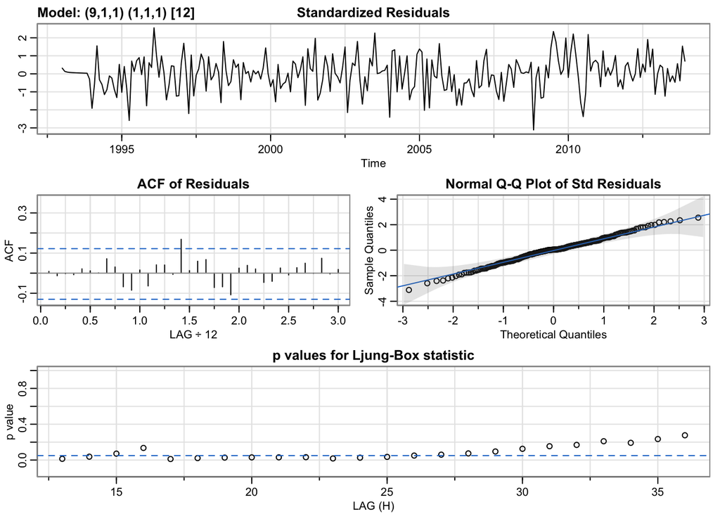

```r
m1
```

```
## $fit
##
## Call:
## arima(x = xdata, order = c(p, d, q), seasonal = list(order = c(P, D, Q), period = S),
##     include.mean = !no.constant, transform.pars = trans, fixed = fixed, optim.control = list(trace = trc,
##         REPORT = 1, reltol = tol))
##
## Coefficients:
##          ar1     ar2     ar3      ar4     ar5     ar6      ar7     ar8      ar9
##       -0.302  0.5771  0.1535  -0.0492  0.0133  0.0351  -0.1481  0.0045  -0.0395
## s.e.   0.156  0.0921  0.0873   0.0782  0.0774  0.0778   0.0772  0.0781   0.0766
##          ma1     sar1    sma1
##       0.7506  -0.7769  0.6598
## s.e.  0.1428   0.1850  0.2182
##
## sigma^2 estimated as 0.0003023:  log likelihood = 628.44,  aic = -1230.87
##
## $degrees_of_freedom
## [1] 227
##
## $ttable
##      Estimate     SE t.value p.value
## ar1   -0.3020 0.1560 -1.9361  0.0541
## ar2    0.5771 0.0921  6.2653  0.0000
## ar3    0.1535 0.0873  1.7588  0.0800
## ar4   -0.0492 0.0782 -0.6294  0.5297
## ar5    0.0133 0.0774  0.1715  0.8640
## ar6    0.0351 0.0778  0.4503  0.6529
## ar7   -0.1481 0.0772 -1.9187  0.0563
## ar8    0.0045 0.0781  0.0581  0.9537
## ar9   -0.0395 0.0766 -0.5150  0.6070
## ma1    0.7506 0.1428  5.2565  0.0000
## sar1  -0.7769 0.1850 -4.2002  0.0000
## sma1   0.6598 0.2182  3.0238  0.0028
##
## $AIC
## [1] -5.150098
##
## $AICc
## [1] -5.144321
##
## $BIC
## [1] -4.961001
```

The residuals are quite correlated and most of the AR parameters are not statistically significant. Let’s see in detail the serial correlation of the residuals.

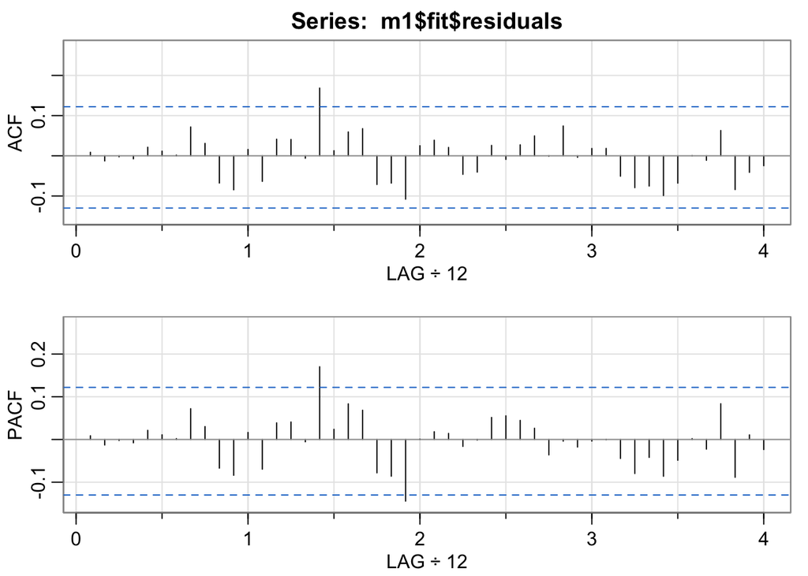

```
##      [,1]  [,2] [,3]  [,4] [,5] [,6] [,7] [,8] [,9] [,10] [,11] [,12] [,13]
## ACF  0.01 -0.01    0 -0.01 0.02 0.01    0 0.07 0.03 -0.07 -0.08  0.02 -0.06
## PACF 0.01 -0.01    0 -0.01 0.02 0.01    0 0.07 0.03 -0.07 -0.08  0.02 -0.07
##      [,14] [,15] [,16] [,17] [,18] [,19] [,20] [,21] [,22] [,23] [,24] [,25]
## ACF   0.04  0.04 -0.01  0.17  0.01  0.06  0.07 -0.07 -0.07 -0.11  0.03  0.04
## PACF  0.04  0.04 -0.01  0.17  0.02  0.08  0.07 -0.08 -0.09 -0.14  0.00  0.02
##      [,26] [,27] [,28] [,29] [,30] [,31] [,32] [,33] [,34] [,35] [,36] [,37]
## ACF   0.02 -0.05 -0.04  0.03 -0.01  0.03  0.05  0.00  0.07  0.00  0.02  0.02
## PACF  0.01 -0.02  0.00  0.05  0.06  0.04  0.03 -0.04  0.00 -0.02  0.00  0.00
##      [,38] [,39] [,40] [,41] [,42] [,43] [,44] [,45] [,46] [,47] [,48]
## ACF  -0.05 -0.08 -0.08 -0.10 -0.07     0 -0.01  0.06 -0.08 -0.04 -0.02
## PACF -0.04 -0.08 -0.04 -0.09 -0.05     0 -0.02  0.08 -0.09  0.01 -0.02
```

```r
acf2(m1$fit$residuals)
```

The ACF and PACF of the residuals do not point clearly to a model but since we have already discarded an AR with large $p$ we will now increase the order of the MA component.

```r
m2=sarima(ly,3,1,9,1,1,1,12)
```

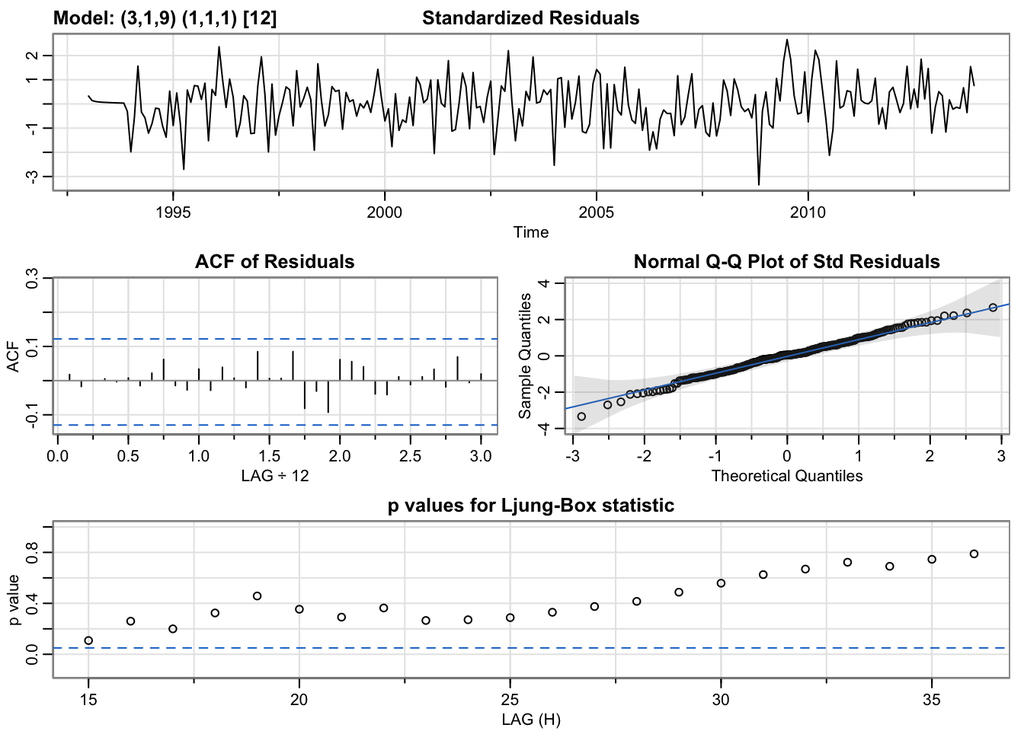

```r
m2
```

```
## $fit
##
## Call:
## arima(x = xdata, order = c(p, d, q), seasonal = list(order = c(P, D, Q), period = S),
##     include.mean = !no.constant, transform.pars = trans, fixed = fixed, optim.control = list(trace = trc,
##         REPORT = 1, reltol = tol))
##
## Coefficients:
##          ar1     ar2      ar3      ma1      ma2     ma3     ma4     ma5     ma6
##       0.8802  0.5167  -0.7168  -0.4923  -0.4595  0.4040  0.0466  0.2205  0.0844
## s.e.  0.1244  0.1945   0.1175   0.1395   0.1660  0.1027  0.0824  0.0865  0.0840
##           ma7     ma8      ma9     sar1    sma1
##       -0.1082  0.2229  -0.1484  -0.7606  0.6352
## s.e.   0.0837  0.0895   0.0872   0.1669  0.2010
##
## sigma^2 estimated as 0.0002823:  log likelihood = 635.85,  aic = -1241.71
##
## $degrees_of_freedom
## [1] 225
##
## $ttable
##      Estimate     SE t.value p.value
## ar1    0.8802 0.1244  7.0755  0.0000
## ar2    0.5167 0.1945  2.6558  0.0085
## ar3   -0.7168 0.1175 -6.0980  0.0000
## ma1   -0.4923 0.1395 -3.5291  0.0005
## ma2   -0.4595 0.1660 -2.7678  0.0061
## ma3    0.4040 0.1027  3.9323  0.0001
## ma4    0.0466 0.0824  0.5649  0.5727
## ma5    0.2205 0.0865  2.5498  0.0114
## ma6    0.0844 0.0840  1.0044  0.3163
## ma7   -0.1082 0.0837 -1.2932  0.1973
## ma8    0.2229 0.0895  2.4911  0.0135
## ma9   -0.1484 0.0872 -1.7019  0.0902
## sar1  -0.7606 0.1669 -4.5564  0.0000
## sma1   0.6352 0.2010  3.1601  0.0018
##
## $AIC
## [1] -5.195422
##
## $AICc
## [1] -5.187577
##
## $BIC
## [1] -4.977234
```

Since several parameters are not statistically significant we will make them zero and re-estimate the model. But we have to use a different function.

```r
m21=Arima(ly, order = c(3,1,9), seasonal=list(order=c(1,1,1), period=12), fixed=c(NA, NA, NA, NA, NA, NA, 0, NA, 0, 0, NA, NA, NA, NA))
m21
```

```
## Series: ly
## ARIMA(3,1,9)(1,1,1)[12]
##
## Coefficients:
##          ar1     ar2      ar3      ma1      ma2     ma3  ma4     ma5  ma6  ma7
##       0.8885  0.4940  -0.6930  -0.5383  -0.3888  0.4066    0  0.2112    0    0
## s.e.  0.1298  0.2286   0.1379   0.1221   0.1684  0.1010    0  0.0721    0    0
##          ma8      ma9     sar1    sma1
##       0.2526  -0.2283  -0.7644  0.6444
## s.e.  0.0744   0.0723   0.1599  0.1881
##
## sigma^2 = 0.0003053:  log likelihood = 634.22
## AIC=-1244.44   AICc=-1243.06   BIC=-1202.73
```

But now we have to recalculated the Ljung-Box statistic.

```r
myLB= function(x.fit){
  res=NULL
  npar= dim(x.fit$var.coef)[1]
for (i in (npar+1):40){
  q=Box.test(x.fit$residuals,lag=i,type="Ljung-Box",fitdf=npar)
  res[i]=q$p.value}
  return(res)}
```

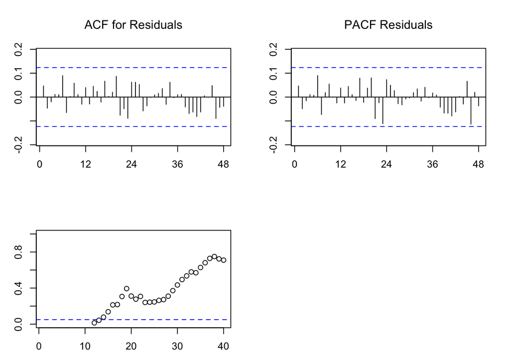

```r
par(mfrow=c(2,2), mar=c(3,3,4,2))
Acf(m21$residuals, type='correlation', lag=maxlag, na.action=na.omit, ylab="", main=expression(paste("ACF for Residuals")))
Acf(m21$residuals, type='partial', lag=maxlag, na.action=na.omit, ylab="", main=expression(paste("PACF Residuals")))
plot(myLB(m21),ylim=c(0,1))
abline(h=0.05,col="blue",lty=2)
```

The residuals remain mostly uncorrelated and all the parameters are statistically significant

Conclusion so far: model m2 explains the serial correlation very well but some parameters are not statistically significant; model m21 has all the parameters statistically significant but there is a bit of serial correlation that remain unexplained.

Now we compare the models using information criteria. Note the AIC, AICc and BIC computed by SARIMA and Arima fucntions are not the same. Therefore we compute those measure for model 2 using Arima

```r
Arima(ly, order = c(3,1,9), seasonal=list(order=c(1,1,1), period=12))
```

```
## Series: ly
## ARIMA(3,1,9)(1,1,1)[12]
##
## Coefficients:
##          ar1     ar2      ar3      ma1      ma2     ma3     ma4     ma5     ma6
##       0.8802  0.5167  -0.7168  -0.4923  -0.4595  0.4040  0.0466  0.2205  0.0844
## s.e.  0.1244  0.1945   0.1175   0.1395   0.1660  0.1027  0.0824  0.0865  0.0840
##           ma7     ma8      ma9     sar1    sma1
##       -0.1082  0.2229  -0.1484  -0.7606  0.6352
## s.e.   0.0837  0.0895   0.0872   0.1669  0.2010
##
## sigma^2 = 0.0003051:  log likelihood = 635.85
## AIC=-1241.71   AICc=-1239.55   BIC=-1189.56
```

Regarding the information criteria we have

[output not shown]

Although the tests point to a non-stationary seasonality, now we try to fit a model to the monthly increases, that is for $d=1.$

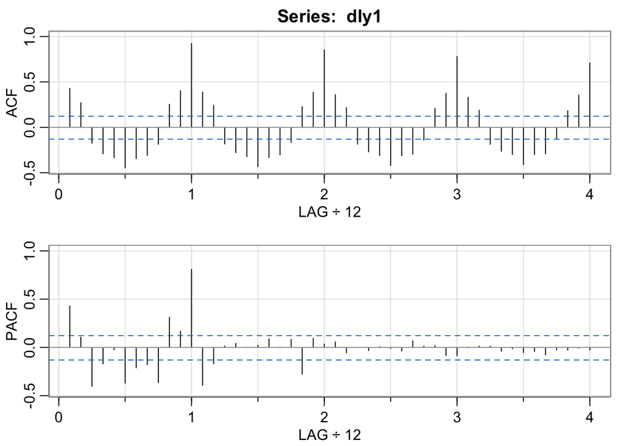

```
##      [,1] [,2]  [,3]  [,4]  [,5]  [,6]  [,7]  [,8]  [,9] [,10] [,11] [,12]
## ACF  0.43 0.27 -0.17 -0.29 -0.34 -0.45 -0.34 -0.31 -0.19  0.25  0.40  0.92
## PACF 0.43 0.11 -0.40 -0.17 -0.02 -0.37 -0.21 -0.18 -0.36  0.31  0.17  0.81
##      [,13] [,14] [,15] [,16] [,17] [,18] [,19] [,20] [,21] [,22] [,23] [,24]
## ACF   0.39  0.24 -0.18 -0.28 -0.32 -0.43 -0.33  -0.3 -0.17  0.23  0.39  0.85
## PACF -0.39 -0.17  0.01  0.04  0.00  0.02  0.09   0.0  0.08 -0.28  0.09  0.03
##      [,25] [,26] [,27] [,28] [,29] [,30] [,31] [,32] [,33] [,34] [,35] [,36]
## ACF   0.36  0.22 -0.19 -0.27 -0.31 -0.42 -0.31 -0.30 -0.14  0.21  0.37  0.78
## PACF  0.06 -0.06  0.00 -0.03  0.01 -0.01 -0.04  0.07  0.01  0.02 -0.08 -0.09
##      [,37] [,38] [,39] [,40] [,41] [,42] [,43] [,44] [,45] [,46] [,47] [,48]
## ACF   0.33  0.19 -0.19 -0.26 -0.30 -0.41 -0.30 -0.29 -0.12  0.18  0.36  0.71
## PACF  0.00  0.01  0.01 -0.04 -0.01 -0.05 -0.04 -0.08 -0.03 -0.03 -0.01 -0.03
```

```r
acf2(dly1)
```

ACF and PACF point to an AR model with a large $p$ and a seasonal component.

```r
o1=sarima(ly,10,1,0,1,0,0,12)
```

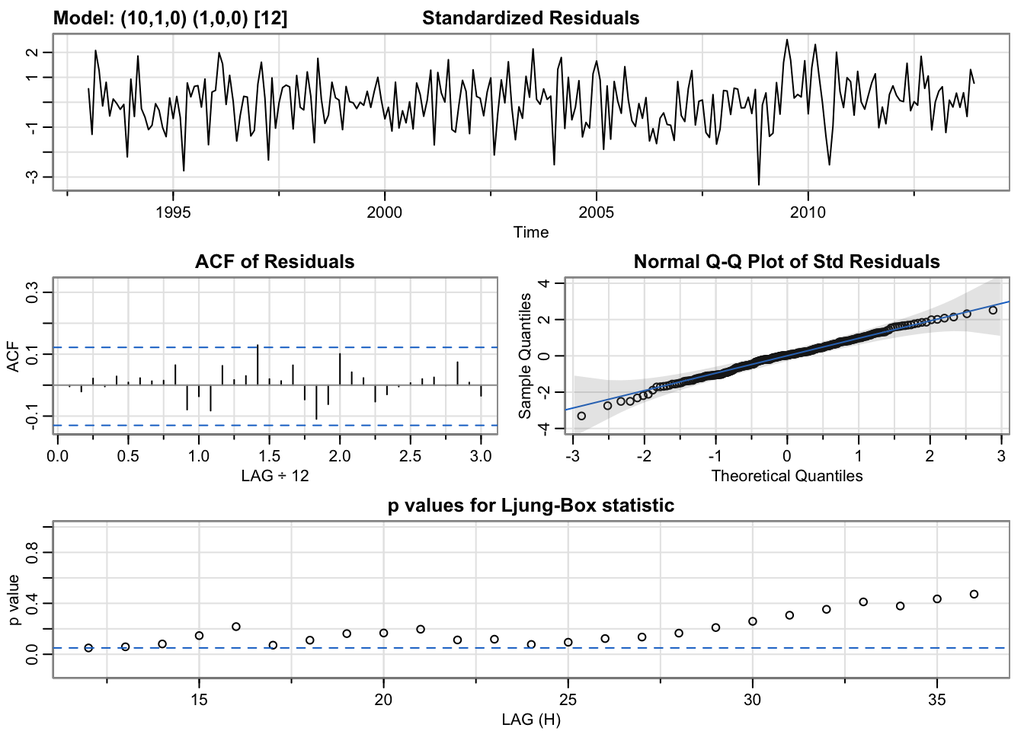

```r
o1
```

```
## $fit
##
## Call:
## arima(x = xdata, order = c(p, d, q), seasonal = list(order = c(P, D, Q), period = S),
##     xreg = constant, transform.pars = trans, fixed = fixed, optim.control = list(trace = trc,
##         REPORT = 1, reltol = tol))
##
## Coefficients:
##          ar1     ar2      ar3      ar4     ar5     ar6      ar7     ar8
##       0.4469  0.2699  -0.0833  -0.0331  0.0440  0.0110  -0.1499  0.1618
## s.e.  0.0632  0.0685   0.0707   0.0695  0.0697  0.0686   0.0700  0.0698
##           ar9     ar10    sar1  constant
##       -0.1461  -0.0397  0.9757    0.0137
## s.e.   0.0689   0.0645  0.0086    0.0399
##
## sigma^2 estimated as 0.0003068:  log likelihood = 640.74,  aic = -1255.49
##
## $degrees_of_freedom
## [1] 239
##
## $ttable
##          Estimate     SE  t.value p.value
## ar1        0.4469 0.0632   7.0716  0.0000
## ar2        0.2699 0.0685   3.9379  0.0001
## ar3       -0.0833 0.0707  -1.1773  0.2403
## ar4       -0.0331 0.0695  -0.4764  0.6342
## ar5        0.0440 0.0697   0.6318  0.5281
## ar6        0.0110 0.0686   0.1609  0.8723
## ar7       -0.1499 0.0700  -2.1422  0.0332
## ar8        0.1618 0.0698   2.3162  0.0214
## ar9       -0.1461 0.0689  -2.1207  0.0350
## ar10      -0.0397 0.0645  -0.6152  0.5390
## sar1       0.9757 0.0086 112.8534  0.0000
## constant   0.0137 0.0399   0.3434  0.7316
##
## $AIC
## [1] -5.001951
##
## $AICc
## [1] -4.996728
##
## $BIC
## [1] -4.819357
```

$a_{i}$ $i=3,4,5,6,10$ are not statistically significant therefore we re-estimate the model

```r
o11=Arima(ly, order = c(9,1,0), seasonal=list(order=c(1,0,0), period=12), fixed=c(NA,NA, 0,0,0,0,NA,NA,NA,NA))
o11
```

```
## Series: ly
## ARIMA(9,1,0)(1,0,0)[12]
##
## Coefficients:
##          ar1     ar2  ar3  ar4  ar5  ar6      ar7     ar8      ar9    sar1
##       0.4359  0.2278    0    0    0    0  -0.1380  0.1527  -0.1691  0.9767
## s.e.  0.0601  0.0602    0    0    0    0   0.0619  0.0654   0.0623  0.0081
##
## sigma^2 = 0.0003167:  log likelihood = 639.59
## AIC=-1265.18   AICc=-1264.72   BIC=-1240.5
```

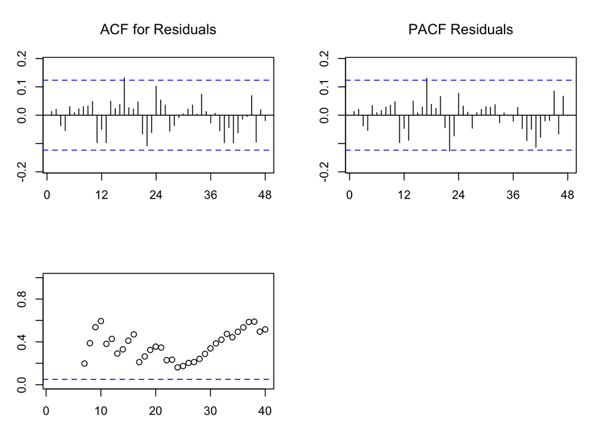

```r
par(mfrow=c(2,2), mar=c(3,3,4,2))
Acf(o11$residuals, type='correlation', lag=maxlag, na.action=na.omit, ylab="", main=expression(paste("ACF for Residuals")))
Acf(o11$residuals, type='partial', lag=maxlag, na.action=na.omit, ylab="", main=expression(paste("PACF Residuals")))
plot(myLB(o11),ylim=c(0,1))
abline(h=0.05,col="blue",lty=2)
```

The residuals are uncorrelated and all the parameters statistically significant. Notice how close to the non-stationarity region the coeficient for the seasonal AR component is. However including more AR or MA components leads to statistically non- significant parameters.

```r
o12=sarima(ly,9,1,0,2,0,0,12)
```

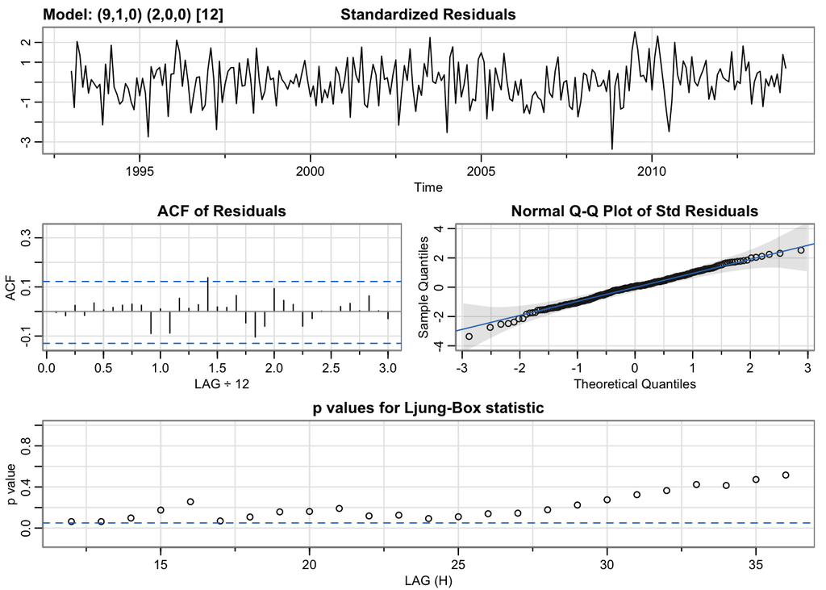

```r
o12
```

```
## $fit
##
## Call:
## arima(x = xdata, order = c(p, d, q), seasonal = list(order = c(P, D, Q), period = S),
##     xreg = constant, transform.pars = trans, fixed = fixed, optim.control = list(trace = trc,
##         REPORT = 1, reltol = tol))
##
## Coefficients:
##          ar1     ar2      ar3      ar4     ar5     ar6      ar7     ar8
##       0.4396  0.2730  -0.0805  -0.0238  0.0408  0.0107  -0.1434  0.1499
## s.e.  0.0643  0.0683   0.0701   0.0704  0.0695  0.0685   0.0697  0.0674
##           ar9    sar1    sar2  constant
##       -0.1589  0.9170  0.0593    0.0138
## s.e.   0.0627  0.0685  0.0696    0.0416
##
## sigma^2 estimated as 0.0003064:  log likelihood = 640.92,  aic = -1255.83
##
## $degrees_of_freedom
## [1] 239
##
## $ttable
##          Estimate     SE t.value p.value
## ar1        0.4396 0.0643  6.8333  0.0000
## ar2        0.2730 0.0683  3.9980  0.0001
## ar3       -0.0805 0.0701 -1.1490  0.2517
## ar4       -0.0238 0.0704 -0.3379  0.7357
## ar5        0.0408 0.0695  0.5876  0.5574
## ar6        0.0107 0.0685  0.1568  0.8755
## ar7       -0.1434 0.0697 -2.0564  0.0408
## ar8        0.1499 0.0674  2.2258  0.0270
## ar9       -0.1589 0.0627 -2.5357  0.0119
## sar1       0.9170 0.0685 13.3953  0.0000
## sar2       0.0593 0.0696  0.8522  0.3949
## constant   0.0138 0.0416  0.3304  0.7414
##
## $AIC
## [1] -5.003323
##
## $AICc
## [1] -4.9981
##
## $BIC
## [1] -4.82073
```

Regarding the information criteria we have

[output not shown]

and therefore o11 has lower information criteria. Which will produce better forecasts remains to be seen. In another video we will use this model to produce forecasts.